# Data Analysis in Inventory Management: Real Case in Managing a Warehouse

Bruce B. Lee

2022-10-14

## About This Project

In this project, I analyzed real online retail transaction datasets to efficiently manage a warehouse inventory.

## Why Inventory Management?

You might wonder, “Why inventory management?” Well, have you ever been in a situation where you were so excited to buy specific goods at a store, only to find out that the store had run out of stock? Now, that would be very disappointing and your image of the store might not be as good as it was before. For a retail company, there are two potential downsides to such situation. One, the company loses a sale. And two, the company risks losing a valued customer. Therefore, it is important that the company has enough stock to meet customers’ needs. However, on the other hand, the company should not have too many items in stock because things can go wrong with those items. This is why doing inventory management with data analysis is necessary for effectively running a company. By conducting data analysis, companies can make data driven decisions on how many items they should prepare in stock.

So how are we going to conduct data analysis to make sure that the online retail company has the right amount of items in stock? We are going to use the company’s **historical transaction data** to figure out the most optimal amount of items to place in stock.

## Get the Historical Data

First, we need to get the company’s historical transaction data from the company’s database. We are going to use 2 years worth of data from 2009 to 2011. Ideally, you would want to use dataset that is more relevant. But for this project, we will use this [dataset](https://www.kaggle.com/datasets/mathchi/online-retail-ii-data-set-from-ml-repository) from 2009 to 2011.

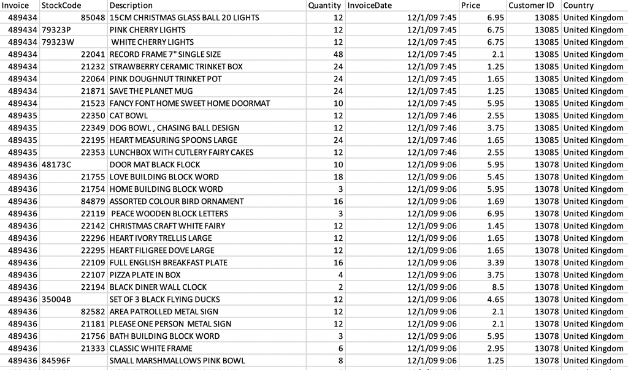

Raw data

## Examine and Wrangle the Data

Before changing the data format and structure, we need to ask ourselves what tools we are going to be using for the analysis, so that we can tailor the dataset specifically for those tools. Since the dataset exceeded 1 million rows, I decided work mostly in SQL and R. Once the plan was set, I wrangled the data so that it is ready for analysis.

I got rid of irrelevant columns of data for this analysis, such as “Invoice” number and “Customer ID.”

Then I transformed “InvoiceDate” column into two columns “Year” and “Month”, using Excel’s `YEAR` and `MONTH` functions

Examining the dataset using filter function in Excel, I discovered that there were negative values in “Quantity” column.

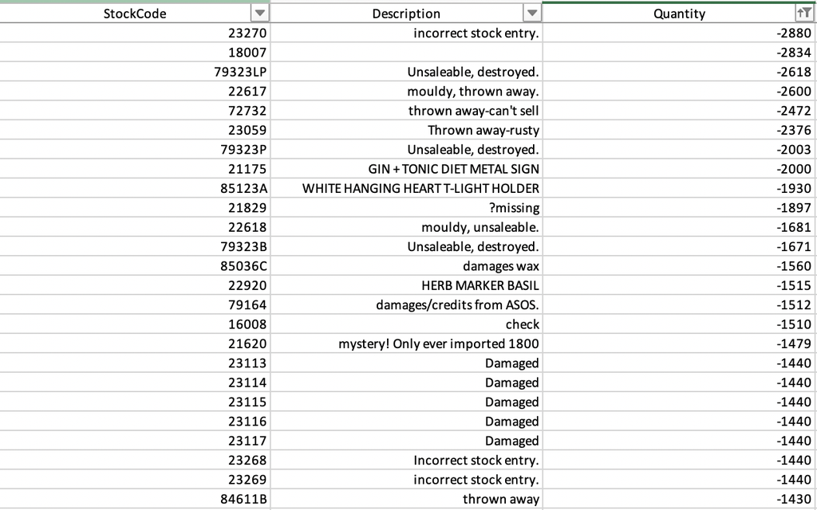

Negative quantity values

This was peculiar, but soon I realized upon close inspection that the rows with negative quantity values were either entry errors or records of unsaleable items. Because these rows were irrelevant to the analysis and would obscure the result of the analysis, I got rid of them.

Additionally, I replaced “£” sign with “Pound” by using `Find & Replace` function, so that data is more readable by softewares in general.

Finally, I decided to divide the dataset into two different datasets, one with “StockCode” and “Description”, and another with “StockCode” and all the information without “Description.” I separated the dataset so that later I could create two tables and work more flexibly in SQL using `JOIN` function. The cleaned datasets looked like this:

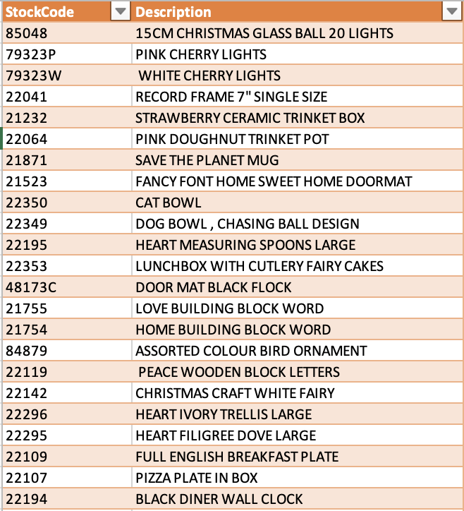

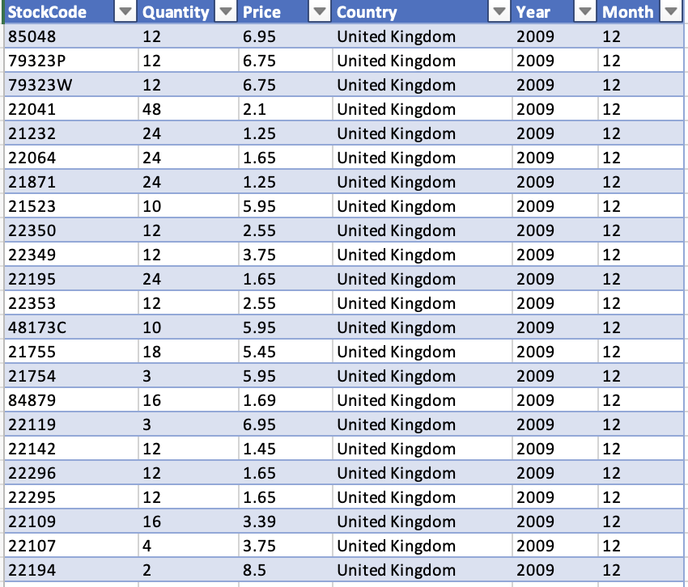

In order to analyze the data using SQL, I exported the cleaned dataset into csv files. Then, I imported the csv files into the DBMS. Make sure to import the 2009-2010 dataset **AND** 2010-2011 dataset!

```sql
CREATE SCHEMA inventory_management;

CREATE TABLE inventory_management.transaction_data (
    StockCode varchar(50) NULL,
    Quantity integer NULL,
    Price real NULL,
    Country varchar(50) NULL,
    Year integer NULL,
    Month integer NULL
);

COPY transaction_data (
    StockCode,
    Quantity,
    Price,
    Country,
    Year,
    Month
)
FROM '/Users/bruce/Desktop/case_studies/retail/archive/2010_2011.csv'
DELIMITER ','
CSV HEADER; --repeat this process for 2010-2011 datset!

CREATE TABLE inventory_management.stockcode (
    StockCode VARCHAR(50) NULL,
    Description VARCHAR(100) NULL
);

COPY stockcode (
    StockCode,
    Description
)
FROM '/Users/bruce/Desktop/case_studies/retail/archive/stockcode.csv'
DELIMITER ','
CSV HEADER;
```

## Analyze the Data

Now it’s time to analyze the data that we’ve cleaned! The main purpose of data analytics in inventory management is to count the items sold in previous period so that we know how much stock is enough to server customers efficiently.

So, first, let’s get an inventory list segmented by country using 2010 data.

```sql
SELECT transaction_data.stockcode, stockcode.description, country, sum(quantity) AS quantity
FROM inventory_management.transaction_data
LEFT JOIN inventory_management.stockcode
ON transaction_data.stockcode = stockcode.stockcode
WHERE stockcode.description IS NOT NULL AND YEAR = 2010
GROUP BY transaction_data.stockcode, stockcode.description, country
ORDER BY stockcode, country;
```

Displaying records 1 - 20

| stockcode | description | country | quantity |
| --- | --- | --- | --- |
| 10002 | INFLATABLE POLITICAL GLOBE | Australia | 36 |
| 10002 | INFLATABLE POLITICAL GLOBE | Denmark | 272 |
| 10002 | INFLATABLE POLITICAL GLOBE | EIRE | 60 |
| 10002 | INFLATABLE POLITICAL GLOBE | France | 720 |
| 10002 | INFLATABLE POLITICAL GLOBE | Germany | 216 |
| 10002 | INFLATABLE POLITICAL GLOBE | Italy | 360 |
| 10002 | INFLATABLE POLITICAL GLOBE | Japan | 1 |
| 10002 | INFLATABLE POLITICAL GLOBE | Netherlands | 12 |
| 10002 | INFLATABLE POLITICAL GLOBE | Spain | 24 |
| 10002 | INFLATABLE POLITICAL GLOBE | Sweden | 12 |
| 10002 | INFLATABLE POLITICAL GLOBE | Switzerland | 108 |
| 10002 | INFLATABLE POLITICAL GLOBE | United Kingdom | 6190 |
| 10002R | JET BLACK LAS VEGAS BRACELET ROUND | United Kingdom | 1 |
| 10080 | ENGLISH ROSE DESIGN SHOPPING BAG | United Kingdom | 98 |
| 10120 | PARTY TIME PENCIL ERASERS | France | 32 |
| 10120 | PARTY TIME PENCIL ERASERS | United Kingdom | 356 |
| 10123C | ASSORTED TUTTI FRUTTI LARGE PURSE | Austria | 12 |
| 10123C | ASSORTED TUTTI FRUTTI LARGE PURSE | France | 144 |
| 10123C | ASSORTED TUTTI FRUTTI LARGE PURSE | Netherlands | 24 |
| 10123C | ASSORTED TUTTI FRUTTI LARGE PURSE | Portugal | 12 |

(Above shows only 20 out of thousands of rows, for technical reasons. The whole list can be downloaded from [here](https://github.com/bruceblee96/bruceblee96.github.io/blob/main/downloads/inventory_list_2010.xlsx).)